# Gene Set Enrichment analysis part II: snRNAseq samples with metformin induced cardiac microtissue

Adapted from Gino Bonazza DCM samples analysis by Magdalena Czepiec and Maks Necki

**Magdalena Czepiec**  
Department of Clinical Immunology / Faculty of Medicine / Jagiellonian University Medical College  
[GitHub](https://github.com/czepiecmagdalena)

**Maks Necki**  
Department of Clinical Immunology / Faculty of Medicine / Jagiellonian University Medical College  
[GitHub](https://github.com/jungwirt)

# 1 Introduction

## 1.1 Setup: Libraries and Environement

```r
# ---- Package lists ----
cran_packages <- c(
  "dplyr",
  "ggplot2",
  "patchwork",
  "htmltools",
  "tidyr",
  "Seurat",
  "stringr",
  "plotly",
  "kableExtra",
  "knitr",
  "sessioninfo"
)

bioc_packages <- c(
  "clusterProfiler",
  "org.Hs.eg.db",
  "enrichplot",
  "ReactomePA"
)

# ---- Function to install & load ----
install_and_load <- function(pkg, bioc = FALSE) {
  if (!requireNamespace(pkg, quietly = TRUE)) {
    if (bioc) {
      if (!requireNamespace("BiocManager", quietly = TRUE)) {
        install.packages("BiocManager")
      }
      BiocManager::install(pkg, ask = FALSE, update = FALSE)
    } else {
      install.packages(pkg)
    }
  }
  library(pkg, character.only = TRUE)
}

# ---- Install & load CRAN packages ----
invisible(lapply(cran_packages, install_and_load))

# ---- Install & load Bioconductor packages ----
invisible(lapply(bioc_packages, install_and_load, bioc = TRUE))

cat("ALL PACKAGES SUCCESSFULLY LOADED")
```

```
## ALL PACKAGES SUCCESSFULLY LOADED
```

## 1.2 Importing files after GO BP Hierarchical Analysis (GSEA part I)

```r
res_hierarchy_tgf_nc <- read.csv("C:/Users/magda/Desktop/Lib_11_MTs_GSEA/Skrypty do publikacji/GSEA part I (GO BP, KEGG, REACTOME, GO BP Hierarchy)/Cardiomyocytes/results_cardio_GO/deg_TGF_vs_NC_cardio_full.csv")
res_hierarchy_met_nc <- read.csv("C:/Users/magda/Desktop/Lib_11_MTs_GSEA/Skrypty do publikacji/GSEA part I (GO BP, KEGG, REACTOME, GO BP Hierarchy)/Cardiomyocytes/results_cardio_GO/deg_MET_vs_NC_cardio_full.csv")
res_hierarchy_mettgf_tgf <- read.csv("C:/Users/magda/Desktop/Lib_11_MTs_GSEA/Skrypty do publikacji/GSEA part I (GO BP, KEGG, REACTOME, GO BP Hierarchy)/Cardiomyocytes/results_cardio_GO/deg_MET_TGF_vs_TGF_cardio_full.csv")
```

## 1.3 Importing Seurat object containing analyzed and processed cardiomyocytes cells from all conditions

```r
Cardio <- readRDS("C:/Users/magda/Desktop/Lib_11_MTs_GSEA/Skrypty do publikacji/GSEA part II (Gene Extraction)/Cardio.rds")
```

# 2 Genes from Pathways Extraction

The following function extracts genes driving enrichment signals from selected biological pathways and integrates them with differentially expressed genes to identify biologically relevant overlaps. By filtering pathways by category, expanding core enrichment gene sets, and mapping gene identifiers, it reconstructs pathway-level signals at the gene level. The subsequent intersection with DEG data highlights genes that are both statistically significant in expression changes and functionally embedded in enriched pathways. This allows prioritization of candidate genes that are not only differentially expressed but also mechanistically linked to specific biological processes. Such gene sets can then be used for downstream analyses like network construction, regulatory inference, biomarker discovery, or comparison of pathway activity across experimental conditions or cell types.

Main function for extraction analysis:

```r
  run_pathway_gene_extraction <- function(
  gsea_df,
  deg_file,
  category = "Metabolism",
  output_name = "genes_of_interest"
  ) {

  if (is.null(gsea_df) || nrow(gsea_df) == 0) {
  return(list(genes_final = NULL, logs = "EMPTY INPUT"))
  }

  logs <- character()

  cat("\n=============================\n")
  cat("Processing category:", category, "\n")
  cat("=============================\n")

  # ---- Input Check ----
  if (is.null(gsea_df)) {
  message("Input GSEA dataframe is NULL - skipping")
  return(NULL)
  }

  # =========================================
  # 1. CATEGORY FILTER
  # =========================================
  # ---- Select only pathways belonging to chosen category ----
  df_category <- gsea_df %>%
    dplyr::filter(Category == category)

  if (nrow(df_category) == 0) {
  return(list(genes_final = NULL, logs = "EMPTY CATEGORY"))
  }

  logs <- c(logs, "\n[1] CATEGORY FILTER\n")
  logs <- c(logs, paste("Rows:", nrow(df_category), "\n"))

  # =========================================
  # 2. GENE EXPANSION
  # =========================================
  # ---- Split core_enrichment into individual genes ----
  df_split <- df_category %>%
    dplyr::mutate(core_enrichment = strsplit(core_enrichment, "/")) %>%
    tidyr::unnest(core_enrichment)

  logs <- c(logs, "\n[2] GENE EXPANSION\n")
  logs <- c(logs, paste("Rows:", nrow(df_split), "\n"))

  # =========================================
  # 3. GENE ID MAPPING
  # =========================================
  # ---- Convert ENTREZ IDs to gene SYMBOLS ----
  gene_map <- clusterProfiler::bitr(
    df_split$core_enrichment,
    fromType = "ENTREZID",
    toType   = "SYMBOL",
    OrgDb    = org.Hs.eg.db
  )

  logs <- c(logs, "\n[3] MAPPING\n")
  logs <- c(logs, paste("Mapped genes:", nrow(gene_map), "\n"))

  # ---- Merge mapping results ----
  df_mapped <- df_split %>%
    dplyr::left_join(gene_map, by = c("core_enrichment" = "ENTREZID"))

  logs <- c(logs, paste("After merge:", nrow(df_mapped),
      "| Missing SYMBOL:", sum(is.na(df_mapped$SYMBOL)), "\n"))

  # =========================================
  # 4. DATA CLEANING
  # =========================================
  # ---- Remove duplicates / NA genes ----
  df_clean <- df_mapped %>%
    dplyr::select(
      pathway = Description,
      gene    = SYMBOL,
      ENTREZID = core_enrichment,
      NES,
      p.adjust
    ) %>%
    dplyr::distinct() %>%
    dplyr::filter(!is.na(gene))

  logs <- c(logs, "\n[4] CLEANING\n")
  logs <- c(logs, paste("Rows:", nrow(df_clean), "\n"))

  # =========================================
  # 5. GSEA RESULTS FILTER
  # =========================================
  # ---- Significant genes (p.adjust and NES) ----
  df_filtered <- df_clean %>%
    dplyr::filter(p.adjust < 0.05, abs(NES) > 1)

  logs <- c(logs, "\n[5] GSEA FILTER\n")
  logs <- c(logs, paste("Rows:", nrow(df_filtered), "\n"))

  # ---- Remove duplicated genes ----
  df_unique <- df_filtered %>%
    dplyr::distinct(gene, .keep_all = TRUE)

  logs <- c(logs, paste("Unique genes:", nrow(df_unique), "\n"))

  # =========================================
  # 6. DEGs (INPUT AND FILTER)
  # =========================================
  deg <- read.csv(deg_file)

  logs <- c(logs, "\n[6] DEG INPUT\n")
  logs <- c(logs, paste("Rows:", nrow(deg), "\n"))

  # ---- Significant DEGs (logFC and FDR) ----
  deg_filtered <- deg %>%
    dplyr::filter(abs(logFC) > 1, FDR < 0.05) %>%
    dplyr::select(gene, logFC, FDR)

  logs <- c(logs, paste("Filtered DEG:", nrow(deg_filtered), "\n"))

  # =========================================
  # 7. INTERSECTION GSEA AND DEGs RESULTS
  # =========================================
  genes_final <- df_unique %>%
    dplyr::inner_join(deg_filtered, by = "gene") %>%
    dplyr::arrange(p.adjust)

  logs <- c(logs, "\n[7] INTERSECTION\n")
  logs <- c(logs, paste("Final genes:", nrow(genes_final), "\n"))

  # =========================================
  # 8. SAVING
  # =========================================
  gene_list <- genes_final$gene

  write.csv(
    gene_list,
    paste0(output_name, "_", category, ".csv"),
    row.names = FALSE
  )

  cat("\nSaved:", paste0(output_name, "_", category, ".csv"), "\n")

  # ---- Return Results ----
  return(list(
    df_category   = df_category,
    df_split      = df_split,
    gene_map      = gene_map,
    df_mapped     = df_mapped,
    df_clean      = df_clean,
    df_filtered   = df_filtered,
    df_unique     = df_unique,
    deg_filtered  = deg_filtered,
    genes_final   = genes_final,
    logs = logs
  ))
}
```

Helper function for plotting empty GSEA datasets:

```r
make_empty_plot <- function(text = "No gene sets found") {
  ggplot() +
    theme_void() +
    theme(
      plot.background = element_rect(color = "black", fill = "white", linewidth = 1),
      panel.background = element_rect(color = "white", fill = "white"),
      plot.margin = margin(10, 10, 10, 10)
    ) +
    annotate(
      "text",
      x = 0.5,
      y = 0.5,
      label = text,
      color = "black",
      size = 6,
      hjust = 0.5
    )
}
```

Function for plotting genes by sample:

```r
  # ---- Plot ----
  plot_vln_batches <- function(
  seurat_obj,
  genes,
  group_by = "Sample",
  ncol = 2,
  nrow = 2,
  output_prefix = "VlnPlot",
  pt.size = 0.5,
  outdir = "results_cardio_GO"
  ) {

  seurat_obj$Sample <- factor(
  seurat_obj$Sample,
  levels = c("CM_NC", "CM_MET", "CM_TGF", "CM_MET_TGF")
  )

  if(!dir.exists(outdir)) dir.create(outdir, recursive = TRUE)

  # ---- Empty Plot ----
  if (is.null(genes) || length(genes) == 0) {
    message("No genes provided - returning empty plot")
  p <- make_empty_plot("No genes provided")

    ggsave(
      filename = file.path(outdir, paste0(output_prefix, "_EMPTY.png")),
      plot = p,
      width = 8,
      height = 6,
      dpi = 150
    )

    return(list(empty_plot = p))
  }

  # ---- Remove duplicates / NA genes ----
  genes <- unique(genes)
  genes <- genes[!is.na(genes)]
  genes <- intersect(genes, rownames(seurat_obj))

  # ---- Empty Plot after removing duplicates / NA genes  ----
  if (length(genes) == 0) {
    message("No valid genes found in Seurat object")

  p <- make_empty_plot("No valid genes found")

  ggsave(
      filename = file.path(outdir, paste0(output_prefix, "_NO_VALID_GENES.png")),
      plot = p,
      width = 8,
      height = 6,
      dpi = 150
    )

    return(list(empty_plot = p))
  }

  batch_size <- ncol * nrow
  batches <- split(genes, ceiling(seq_along(genes) / batch_size))
  n_batches <- length(batches)
  n_genes <- length(genes)

  cat("Total genes:", n_genes, "\n")
  cat("Number of batches:", n_batches, "\n")

  plot_list <- list()

  # ---- Main Loop ----
  for (i in seq_along(batches)) {
  batch_genes <- batches[[i]]

  #cat("Plotting batch", i, "with", length(batch_genes), "genes\n")

  # ---- Empty batch ----
  if (length(batch_genes) == 0) {
  p <- make_empty_plot(paste0("Empty batch ", i))
  } else {
      p <- VlnPlot(
        seurat_obj,
        features = batch_genes,
        group.by = group_by,
        pt.size = pt.size,
        ncol = ncol,
        combine = TRUE
      ) + theme(legend.position = 'none')
    }

  # ---- Saving ----
    ggsave(
      filename = file.path(outdir, paste0(output_prefix, "_batch_", i, ".png")),
      plot = p,
      width = ncol * 12,
      height = nrow * 9,
      dpi = 150
    )
    plot_list[[paste0("batch_", i)]] <- p
  }
  return(plot_list)
  }
```

# 3 Showing extracted genes from pathways and from DEGs from each category for all comparisons across cardiomyocyte cluster

## 3.1 Metabolism Category

### 3.1.1 MET_TGF vs TGF

#### 3.1.1.1 Gene Extraction

```r
dir.create("results_cardio_extraction_metabolism", recursive = TRUE)

res_mettgf_tgf_metab <- run_pathway_gene_extraction(
  gsea_df = res_hierarchy_mettgf_tgf,
  deg_file = "C:/Users/magda/Desktop/Lib_11_MTs_GSEA/deg_MET_TGF_vs_TGF_cardio.csv",
  category = "Metabolism",
  output_name = file.path("results_cardio_extraction_metabolism", "mettgf_vs_tgf")
)
```

```
##
## =============================
## Processing category: Metabolism
## =============================
```

```
##
## Saved: results_cardio_extraction_metabolism/mettgf_vs_tgf_Metabolism.csv
```

#### 3.1.1.2 Intermediate QC Logs

```r
cat(paste(unlist(res_mettgf_tgf_metab$logs), collapse = "\n"))
```

```
##
## [1] CATEGORY FILTER
##
## Rows: 7
##
##
## [2] GENE EXPANSION
##
## Rows: 489
##
##
## [3] MAPPING
##
## Mapped genes: 261
##
## After merge: 489 | Missing SYMBOL: 0
##
##
## [4] CLEANING
##
## Rows: 489
##
##
## [5] GSEA FILTER
##
## Rows: 489
##
## Unique genes: 261
##
##
## [6] DEG INPUT
##
## Rows: 6998
##
## Filtered DEG: 35
##
##
## [7] INTERSECTION
##
## Final genes: 4
```

#### 3.1.1.3 Extracted Gene Violin Plots

```r
plots_mettgf_tgf <- plot_vln_batches(
  seurat_obj = Cardio,
  genes = res_mettgf_tgf_metab$genes_final$gene,
  group_by = "Sample",
  ncol = 2,
  nrow = 2,
  output_prefix = "Cardio_Vln_metabolism_mettgf_tgf",
  outdir = "results_cardio_extraction_metabolism",
  pt.size = 0.5
)
```

```
## Total genes: 4
## Number of batches: 1
```

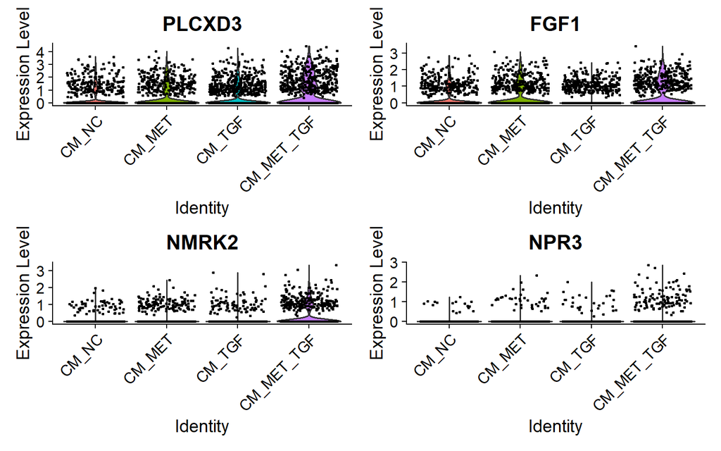

```r
invisible(lapply(plots_mettgf_tgf, print))
```

### 3.1.2 TGF vs NC

#### 3.1.2.1 Gene Extraction

```r
dir.create("results_cardio_extraction_metabolism", recursive = TRUE)

res_tgf_nc_metab <- run_pathway_gene_extraction(
  gsea_df = res_hierarchy_tgf_nc,
  deg_file = "C:/Users/magda/Desktop/Lib_11_MTs_GSEA/deg_TGF_vs_NC_cardio.csv",
  category = "Metabolism",
  output_name = file.path("results_cardio_extraction_metabolism", "tgf_vs_nc")
)
```

```
##
## =============================
## Processing category: Metabolism
## =============================
```

```
##
## Saved: results_cardio_extraction_metabolism/tgf_vs_nc_Metabolism.csv
```

#### 3.1.2.2 Intermediate QC Logs

```r
cat(paste(unlist(res_tgf_nc_metab$logs), collapse = "\n"))
```

```
##
## [1] CATEGORY FILTER
##
## Rows: 5
##
##
## [2] GENE EXPANSION
##
## Rows: 544
##
##
## [3] MAPPING
##
## Mapped genes: 440
##
## After merge: 544 | Missing SYMBOL: 0
##
##
## [4] CLEANING
##
## Rows: 544
##
##
## [5] GSEA FILTER
##
## Rows: 544
##
## Unique genes: 440
##
##
## [6] DEG INPUT
##
## Rows: 7282
##
## Filtered DEG: 75
##
##
## [7] INTERSECTION
##
## Final genes: 2
```

#### 3.1.2.3 Extracted Gene Violin Plots

```r
plots_tgf_nc <- plot_vln_batches(
  seurat_obj = Cardio,
  genes = res_tgf_nc_metab$genes_final$gene,
  group_by = "Sample",
  ncol = 2,
  nrow = 2,
  output_prefix = "Cardio_Vln_metabolism_tgf_nc",
  outdir = "results_cardio_extraction_metabolism",
  pt.size = 0.5
)
```

```
## Total genes: 2
## Number of batches: 1
```

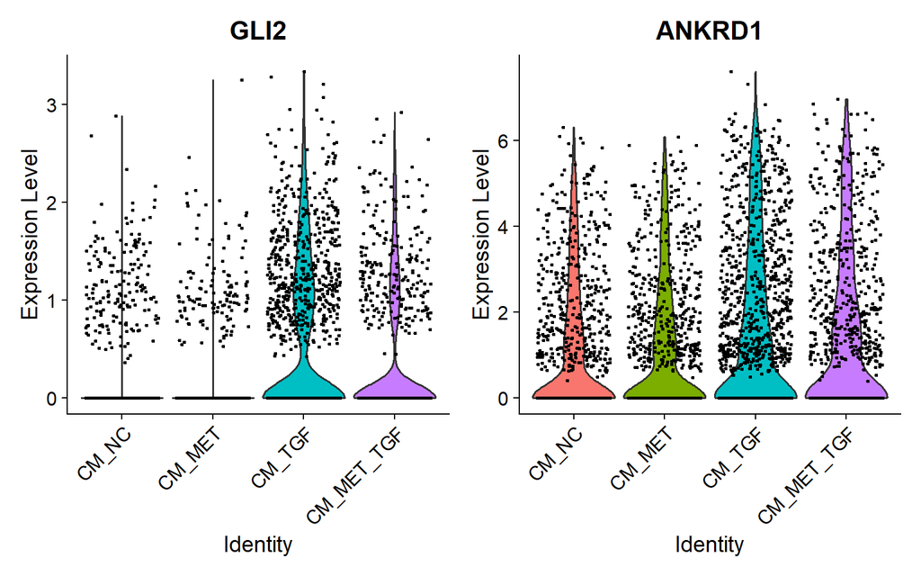

```r
invisible(lapply(plots_tgf_nc, print))
```

### 3.1.3 MET vs NC

#### 3.1.3.1 Gene Extraction

```r
dir.create("results_cardio_extraction_metabolism", recursive = TRUE)

res_met_nc_metab <- run_pathway_gene_extraction(
  gsea_df = res_hierarchy_met_nc,
  deg_file = "C:/Users/magda/Desktop/Lib_11_MTs_GSEA/deg_MET_vs_NC_cardio.csv",
  category = "Metabolism",
  output_name = file.path("results_cardio_extraction_metabolism", "met_vs_nc")
)
```

```
##
## =============================
## Processing category: Metabolism
## =============================
```

```
##
## Saved: results_cardio_extraction_metabolism/met_vs_nc_Metabolism.csv
```

#### 3.1.3.2 Intermediate QC Logs

```r
cat(paste(unlist(res_met_nc_metab$logs), collapse = "\n"))
```

```
##
## [1] CATEGORY FILTER
##
## Rows: 14
##
##
## [2] GENE EXPANSION
##
## Rows: 336
##
##
## [3] MAPPING
##
## Mapped genes: 171
##
## After merge: 336 | Missing SYMBOL: 0
##
##
## [4] CLEANING
##
## Rows: 336
##
##
## [5] GSEA FILTER
##
## Rows: 336
##
## Unique genes: 171
##
##
## [6] DEG INPUT
##
## Rows: 6919
##
## Filtered DEG: 15
##
##
## [7] INTERSECTION
##
## Final genes: 1
```

#### 3.1.3.3 Extracted Gene Violin Plots

```r
plots_met_nc <- plot_vln_batches(
  seurat_obj = Cardio,
  genes = res_met_nc_metab$genes_final$gene,
  group_by = "Sample",
  ncol = 2,
  nrow = 2,
  output_prefix = "Cardio_Vln_metabolism_met_nc",
  outdir = "results_cardio_extraction_metabolism",
  pt.size = 0.5
)
```

```
## Total genes: 1
## Number of batches: 1
```

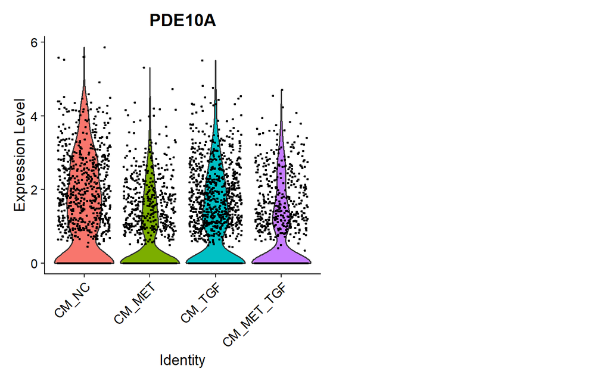

```r
invisible(lapply(plots_met_nc, print))
```

## 3.2 Immune Category

### 3.2.1 MET_TGF vs TGF

#### 3.2.1.1 Gene Extraction

```r
dir.create("results_cardio_extraction_immune", recursive = TRUE)

res_mettgf_tgf_immune <- run_pathway_gene_extraction(
  gsea_df = res_hierarchy_mettgf_tgf,
  deg_file = "C:/Users/magda/Desktop/Lib_11_MTs_GSEA/deg_MET_TGF_vs_TGF_cardio.csv",
  category = "Immune",
  output_name = file.path("results_cardio_extraction_immune", "mettgf_vs_tgf")
)
```

```
##
## =============================
## Processing category: Immune
## =============================
```

```
##
## Saved: results_cardio_extraction_immune/mettgf_vs_tgf_Immune.csv
```

#### 3.2.1.2 Intermediate QC Logs

```r
cat(paste(unlist(res_mettgf_tgf_immune$logs), collapse = "\n"))
```

```
##
## [1] CATEGORY FILTER
##
## Rows: 3
##
##
## [2] GENE EXPANSION
##
## Rows: 159
##
##
## [3] MAPPING
##
## Mapped genes: 66
##
## After merge: 159 | Missing SYMBOL: 0
##
##
## [4] CLEANING
##
## Rows: 159
##
##
## [5] GSEA FILTER
##
## Rows: 159
##
## Unique genes: 66
##
##
## [6] DEG INPUT
##
## Rows: 6998
##
## Filtered DEG: 35
##
##
## [7] INTERSECTION
##
## Final genes: 4
```

#### 3.2.1.3 Extracted Gene Violin Plots

```r
plots_mettgf_tgf <- plot_vln_batches(
  seurat_obj = Cardio,
  genes = res_mettgf_tgf_immune$genes_final$gene,
  group_by = "Sample",
  ncol = 2,
  nrow = 2,
  output_prefix = "Cardio_Vln_immune_mettgf_tgf",
  outdir = "results_cardio_extraction_immune",
  pt.size = 0.5
)
```

```
## Total genes: 4
## Number of batches: 1
```

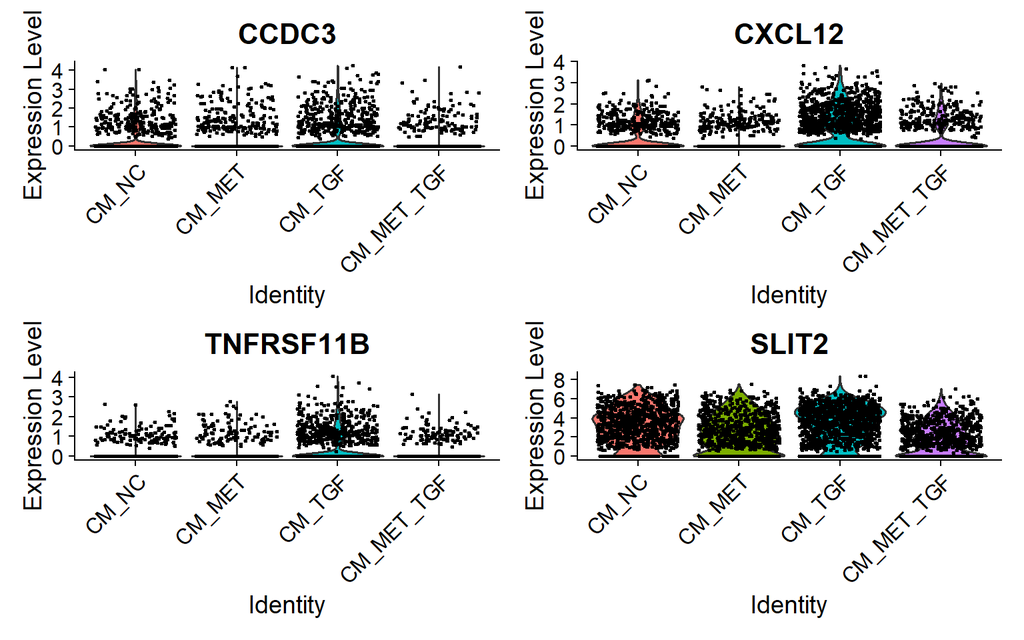

```r
invisible(lapply(plots_mettgf_tgf, print))
```

### 3.2.2 TGF vs NC

#### 3.2.2.1 Gene Extraction

```r
dir.create("results_cardio_extraction_immune", recursive = TRUE)

res_tgf_nc_immune <- run_pathway_gene_extraction(
  gsea_df = res_hierarchy_tgf_nc,
  deg_file = "C:/Users/magda/Desktop/Lib_11_MTs_GSEA/deg_TGF_vs_NC_cardio.csv",
  category = "Immune",
  output_name = file.path("results_cardio_extraction_immune", "tgf_vs_nc")
)
```

```
##
## =============================
## Processing category: Immune
## =============================
```

#### 3.2.2.2 Intermediate QC Logs

```r
cat(paste(unlist(res_tgf_nc_immune$logs), collapse = "\n"))
```

```
## EMPTY CATEGORY
```

#### 3.2.2.3 Extracted Gene Violin Plots

```r
plots_tgf_nc <- plot_vln_batches(
  seurat_obj = Cardio,
  genes = res_tgf_nc_immune$genes_final$gene,
  group_by = "Sample",
  ncol = 2,
  nrow = 2,
  output_prefix = "Cardio_Vln_immune_tgf_nc",
  outdir = "results_cardio_extraction_immune",
  pt.size = 0.5
)

invisible(lapply(plots_tgf_nc, print))
```

[output not shown]

### 3.2.3 MET vs NC

#### 3.2.3.1 Gene Extraction

```r
dir.create("results_cardio_extraction_immune", recursive = TRUE)

res_met_nc_immune <- run_pathway_gene_extraction(
  gsea_df = res_hierarchy_met_nc,
  deg_file = "C:/Users/magda/Desktop/Lib_11_MTs_GSEA/deg_MET_vs_NC_cardio.csv",
  category = "immune",
  output_name = file.path("results_cardio_extraction_immune", "met_vs_nc")
)
```

```
##
## =============================
## Processing category: immune
## =============================
```

#### 3.2.3.2 Intermediate QC Logs

```r
cat(paste(unlist(res_met_nc_immune$logs), collapse = "\n"))
```

```
## EMPTY CATEGORY
```

#### 3.2.3.3 Extracted Gene Violin Plots

```r
plots_met_nc <- plot_vln_batches(
  seurat_obj = Cardio,
  genes = res_met_nc_immune$genes_final$gene,
  group_by = "Sample",
  ncol = 2,
  nrow = 2,
  output_prefix = "Cardio_Vln_immune_met_nc",
  outdir = "results_cardio_extraction_immune",
  pt.size = 0.5
)

invisible(lapply(plots_met_nc, print))
```

[output not shown]

## 3.3 Signaling Category

### 3.3.1 MET_TGF vs TGF

#### 3.3.1.1 Gene Extraction

```r
dir.create("results_cardio_extraction_signaling", recursive = TRUE)

res_mettgf_tgf_signaling <- run_pathway_gene_extraction(
  gsea_df = res_hierarchy_mettgf_tgf,
  deg_file = "C:/Users/magda/Desktop/Lib_11_MTs_GSEA/deg_MET_TGF_vs_TGF_cardio.csv",
  category = "Signaling",
  output_name = file.path("results_cardio_extraction_signaling", "mettgf_vs_tgf")
)
```

```
##
## =============================
## Processing category: Signaling
## =============================
```

```
##
## Saved: results_cardio_extraction_signaling/mettgf_vs_tgf_Signaling.csv
```

#### 3.3.1.2 Intermediate QC Logs

```r
cat(paste(unlist(res_mettgf_tgf_signaling$logs), collapse = "\n"))
```

```
##
## [1] CATEGORY FILTER
##
## Rows: 11
##
##
## [2] GENE EXPANSION
##
## Rows: 702
##
##
## [3] MAPPING
##
## Mapped genes: 309
##
## After merge: 702 | Missing SYMBOL: 0
##
##
## [4] CLEANING
##
## Rows: 702
##
##
## [5] GSEA FILTER
##
## Rows: 702
##
## Unique genes: 309
##
##
## [6] DEG INPUT
##
## Rows: 6998
##
## Filtered DEG: 35
##
##
## [7] INTERSECTION
##
## Final genes: 11
```

#### 3.3.1.3 Extracted Gene Violin Plots

```r
plots_mettgf_tgf <- plot_vln_batches(
  seurat_obj = Cardio,
  genes = res_mettgf_tgf_signaling$genes_final$gene,
  group_by = "Sample",
  ncol = 2,
  nrow = 2,
  output_prefix = "Cardio_Vln_signaling_mettgf_tgf",
  outdir = "results_cardio_extraction_signaling",
  pt.size = 0.5
)
```

```
## Total genes: 11
## Number of batches: 3
```

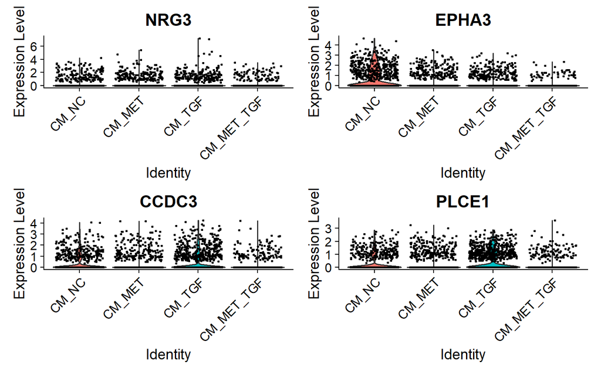

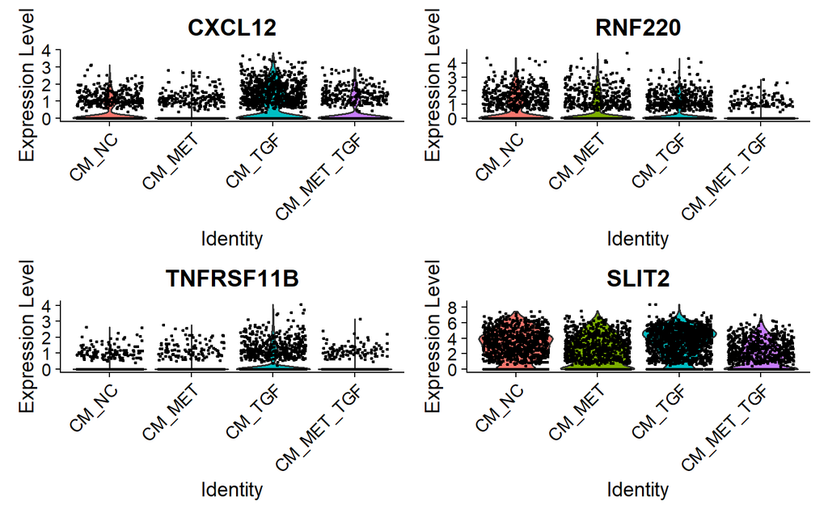

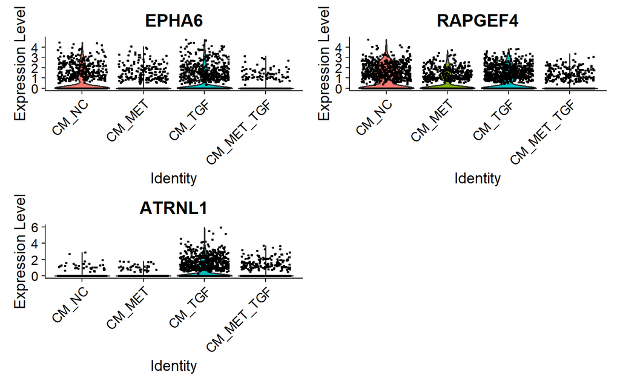

```r
invisible(lapply(plots_mettgf_tgf, print))
```

### 3.3.2 TGF vs NC

#### 3.3.2.1 Gene Extraction

```r
dir.create("results_cardio_extraction_signaling", recursive = TRUE)

res_tgf_nc_signaling <- run_pathway_gene_extraction(
  gsea_df = res_hierarchy_tgf_nc,
  deg_file = "C:/Users/magda/Desktop/Lib_11_MTs_GSEA/deg_TGF_vs_NC_cardio.csv",
  category = "Signaling",
  output_name = file.path("results_cardio_extraction_signaling", "tgf_vs_nc")
)
```

```
##
## =============================
## Processing category: Signaling
## =============================
```

```
##
## Saved: results_cardio_extraction_signaling/tgf_vs_nc_Signaling.csv
```

#### 3.3.2.2 Intermediate QC Logs

```r
cat(paste(unlist(res_tgf_nc_signaling$logs), collapse = "\n"))
```

```
##
## [1] CATEGORY FILTER
##
## Rows: 10
##
##
## [2] GENE EXPANSION
##
## Rows: 365
##
##
## [3] MAPPING
##
## Mapped genes: 255
##
## After merge: 365 | Missing SYMBOL: 0
##
##
## [4] CLEANING
##
## Rows: 365
##
##
## [5] GSEA FILTER
##
## Rows: 365
##
## Unique genes: 255
##
##
## [6] DEG INPUT
##
## Rows: 7282
##
## Filtered DEG: 75
##
##
## [7] INTERSECTION
##
## Final genes: 15
```

#### 3.3.2.3 Extracted Gene Violin Plots

```r
plots_tgf_nc <- plot_vln_batches(
  seurat_obj = Cardio,
  genes = res_tgf_nc_signaling$genes_final$gene,
  group_by = "Sample",
  ncol = 2,
  nrow = 2,
  output_prefix = "Cardio_Vln_signaling_tgf_nc",
  outdir = "results_cardio_extraction_signaling",
  pt.size = 0.5
)
```

```
## Total genes: 15
## Number of batches: 4
```

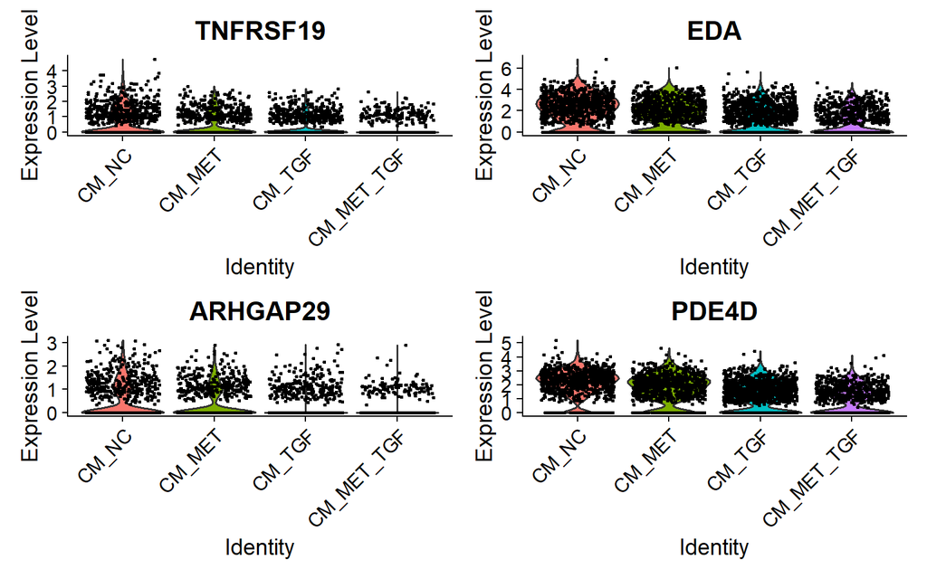

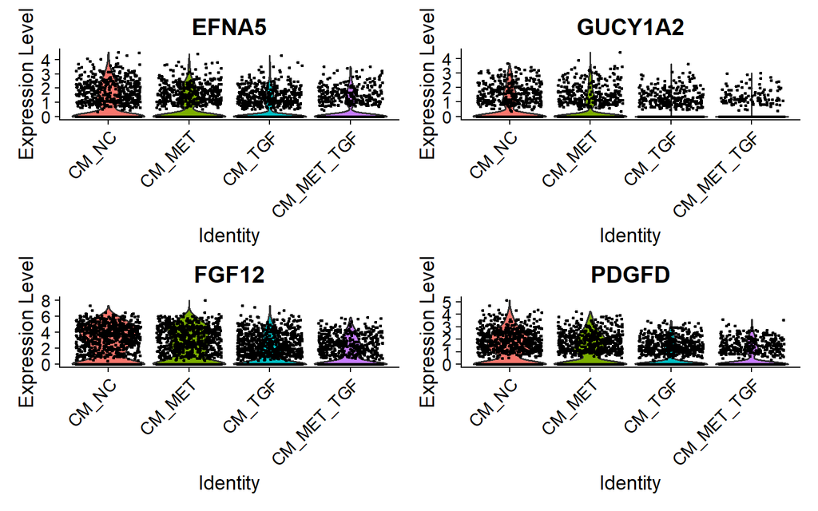

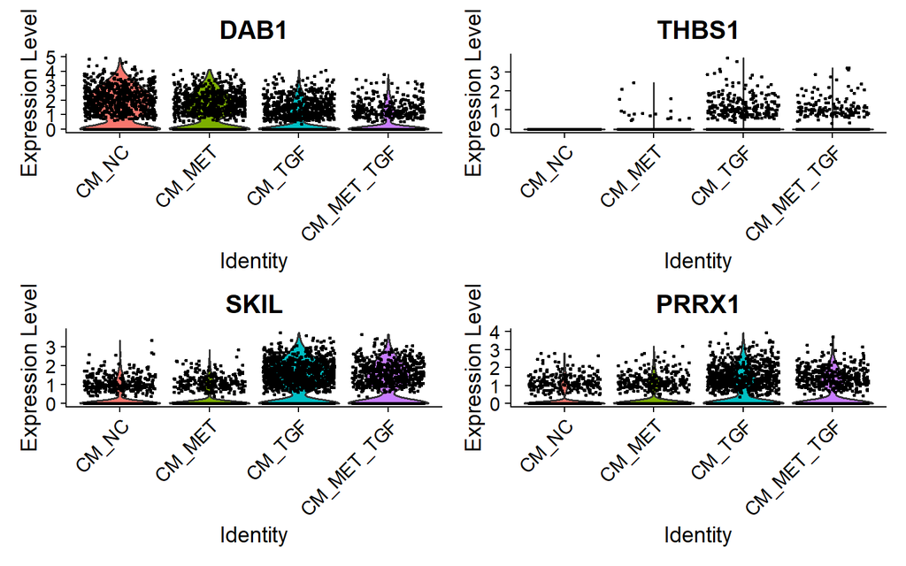

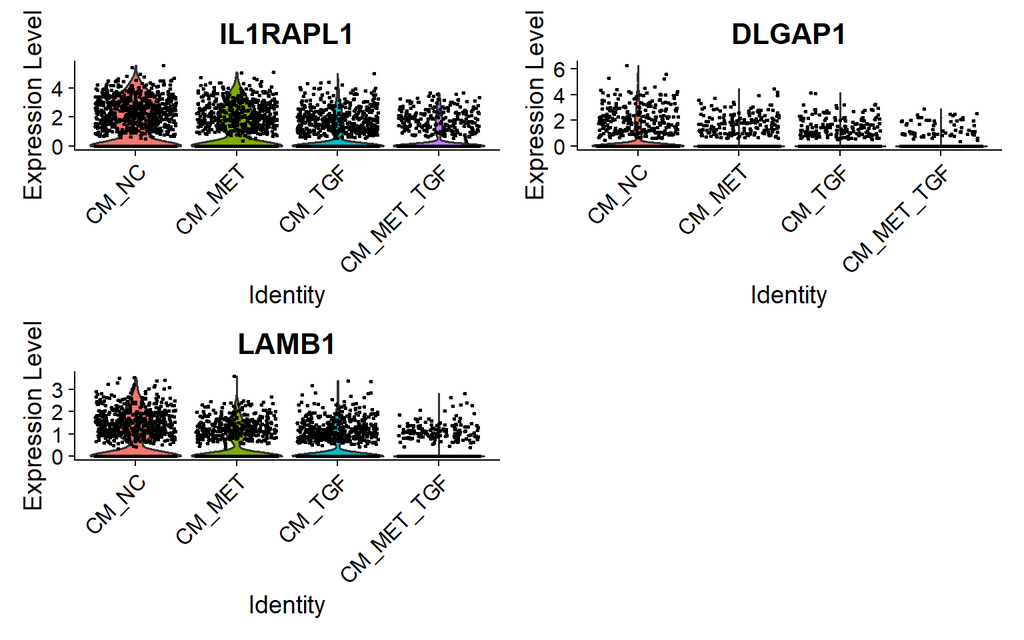

```r
invisible(lapply(plots_tgf_nc, print))
```

### 3.3.3 MET vs NC

#### 3.3.3.1 Gene Extraction

```r
dir.create("results_cardio_extraction_signaling", recursive = TRUE)

res_met_nc_signaling <- run_pathway_gene_extraction(
  gsea_df = res_hierarchy_met_nc,
  deg_file = "C:/Users/magda/Desktop/Lib_11_MTs_GSEA/deg_MET_vs_NC_cardio.csv",
  category = "Signaling",
  output_name = file.path("results_cardio_extraction_signaling", "met_vs_nc")
)
```

```
##
## =============================
## Processing category: Signaling
## =============================
```

```
##
## Saved: results_cardio_extraction_signaling/met_vs_nc_Signaling.csv
```

#### 3.3.3.2 Intermediate QC Logs

```r
cat(paste(unlist(res_met_nc_signaling$logs), collapse = "\n"))
```

```
##
## [1] CATEGORY FILTER
##
## Rows: 31
##
##
## [2] GENE EXPANSION
##
## Rows: 2890
##
##
## [3] MAPPING
##
## Mapped genes: 567
##
## After merge: 2890 | Missing SYMBOL: 0
##
##
## [4] CLEANING
##
## Rows: 2890
##
##
## [5] GSEA FILTER
##
## Rows: 2890
##
## Unique genes: 567
##
##
## [6] DEG INPUT
##
## Rows: 6919
##
## Filtered DEG: 15
##
##
## [7] INTERSECTION
##
## Final genes: 5
```

#### 3.3.3.3 Extracted Gene Violin Plots

```r
plots_met_nc <- plot_vln_batches(
  seurat_obj = Cardio,
  genes = res_met_nc_signaling$genes_final$gene,
  group_by = "Sample",
  ncol = 2,
  nrow = 2,
  output_prefix = "Cardio_Vln_signaling_met_nc",
  outdir = "results_cardio_extraction_signaling",
  pt.size = 0.5
)
```

```
## Total genes: 5
## Number of batches: 2
```

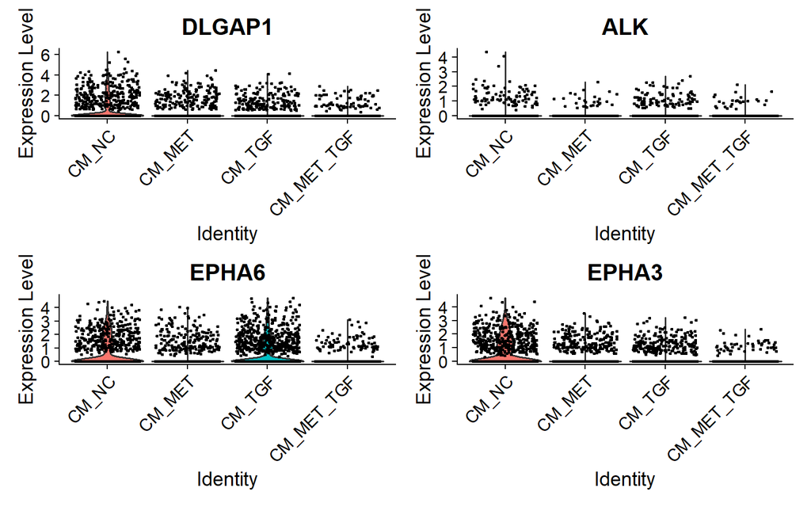

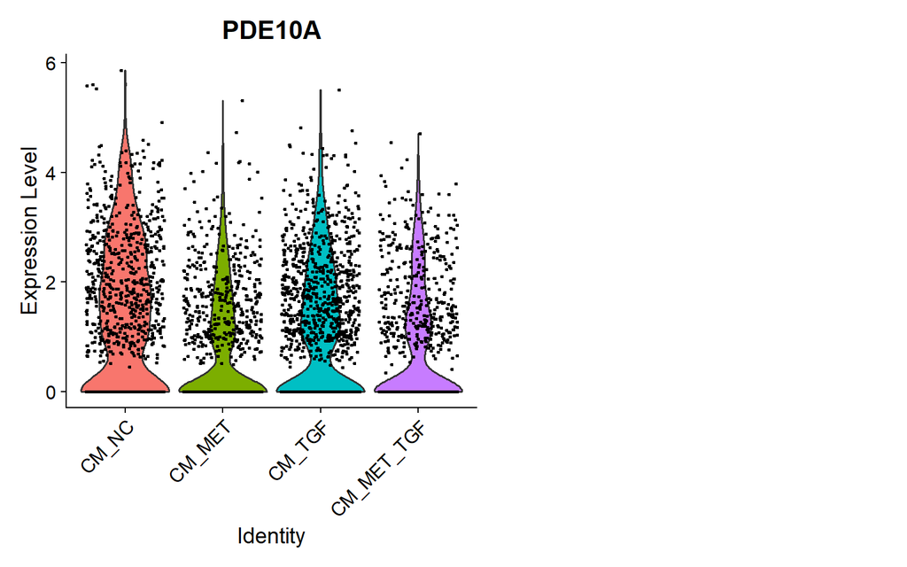

```r
invisible(lapply(plots_met_nc, print))
```

## 3.4 Migration Category

### 3.4.1 MET_TGF vs TGF

#### 3.4.1.1 Gene Extraction

```r
dir.create("results_cardio_extraction_migration", recursive = TRUE)

res_mettgf_tgf_migration <- run_pathway_gene_extraction(
  gsea_df = res_hierarchy_mettgf_tgf,
  deg_file = "C:/Users/magda/Desktop/Lib_11_MTs_GSEA/deg_MET_TGF_vs_TGF_cardio.csv",
  category = "Migration",
  output_name = file.path("results_cardio_extraction_migration", "mettgf_vs_tgf")
)
```

```
##
## =============================
## Processing category: Migration
## =============================
```

```
##
## Saved: results_cardio_extraction_migration/mettgf_vs_tgf_Migration.csv
```

#### 3.4.1.2 Intermediate QC Logs

```r
cat(paste(unlist(res_mettgf_tgf_migration$logs), collapse = "\n"))
```

```
##
## [1] CATEGORY FILTER
##
## Rows: 19
##
##
## [2] GENE EXPANSION
##
## Rows: 1016
##
##
## [3] MAPPING
##
## Mapped genes: 148
##
## After merge: 1016 | Missing SYMBOL: 0
##
##
## [4] CLEANING
##
## Rows: 1016
##
##
## [5] GSEA FILTER
##
## Rows: 1016
##
## Unique genes: 148
##
##
## [6] DEG INPUT
##
## Rows: 6998
##
## Filtered DEG: 35
##
##
## [7] INTERSECTION
##
## Final genes: 6
```

#### 3.4.1.3 Extracted Gene Violin Plots

```r
plots_mettgf_tgf <- plot_vln_batches(
  seurat_obj = Cardio,
  genes = res_mettgf_tgf_migration$genes_final$gene,
  group_by = "Sample",
  ncol = 2,
  nrow = 2,
  output_prefix = "Cardio_Vln_migration_mettgf_tgf",
  outdir = "results_cardio_extraction_migration",
  pt.size = 0.5
)
```

```
## Total genes: 6
## Number of batches: 2
```

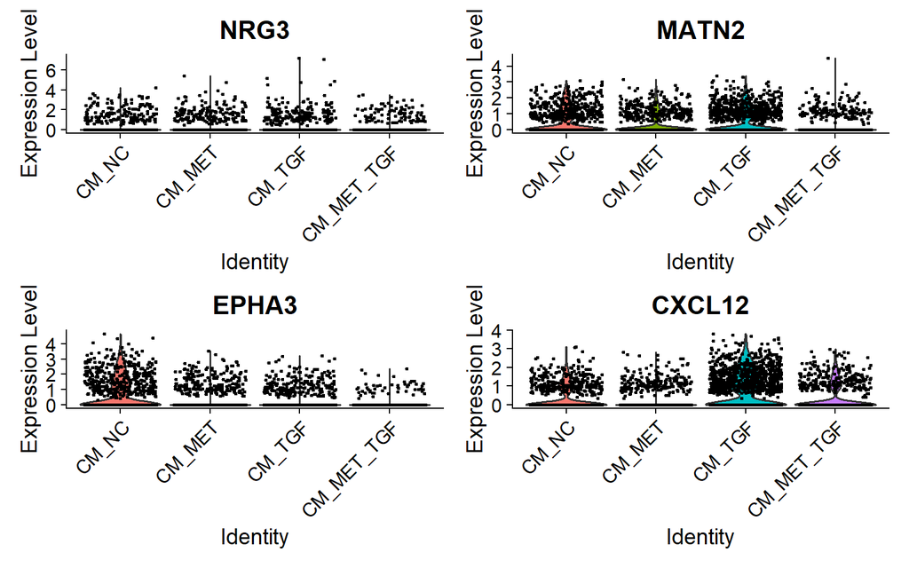

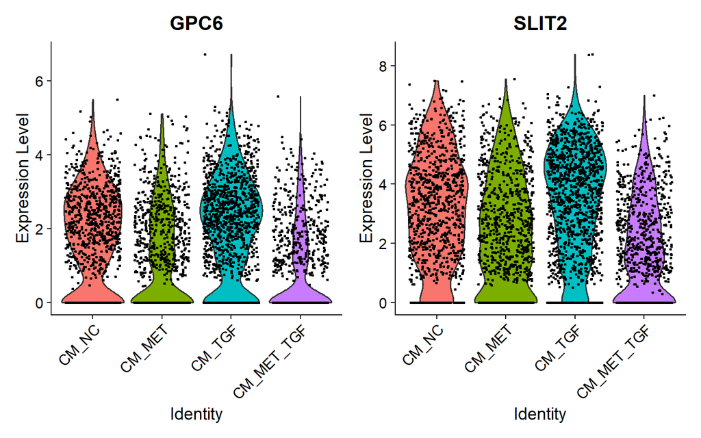

```r
invisible(lapply(plots_mettgf_tgf, print))
```

### 3.4.2 TGF vs NC

#### 3.4.2.1 Gene Extraction

```r
dir.create("results_cardio_extraction_migration", recursive = TRUE)

res_tgf_nc_migration <- run_pathway_gene_extraction(
  gsea_df = res_hierarchy_tgf_nc,
  deg_file = "C:/Users/magda/Desktop/Lib_11_MTs_GSEA/deg_TGF_vs_NC_cardio.csv",
  category = "Migration",
  output_name = file.path("results_cardio_extraction_migration", "tgf_vs_nc")
)
```

```
##
## =============================
## Processing category: Migration
## =============================
```

```
##
## Saved: results_cardio_extraction_migration/tgf_vs_nc_Migration.csv
```

#### 3.4.2.2 Intermediate QC Logs

```r
cat(paste(unlist(res_tgf_nc_migration$logs), collapse = "\n"))
```

```
##
## [1] CATEGORY FILTER
##
## Rows: 4
##
##
## [2] GENE EXPANSION
##
## Rows: 521
##
##
## [3] MAPPING
##
## Mapped genes: 170
##
## After merge: 521 | Missing SYMBOL: 0
##
##
## [4] CLEANING
##
## Rows: 521
##
##
## [5] GSEA FILTER
##
## Rows: 521
##
## Unique genes: 170
##
##
## [6] DEG INPUT
##
## Rows: 7282
##
## Filtered DEG: 75
##
##
## [7] INTERSECTION
##
## Final genes: 8
```

#### 3.4.2.3 Extracted Gene Violin Plots

```r
plots_tgf_nc <- plot_vln_batches(
  seurat_obj = Cardio,
  genes = res_tgf_nc_migration$genes_final$gene,
  group_by = "Sample",
  ncol = 2,
  nrow = 2,
  output_prefix = "Cardio_Vln_migration_tgf_nc",
  outdir = "results_cardio_extraction_migration",
  pt.size = 0.5
)
```

```
## Total genes: 8
## Number of batches: 2
```

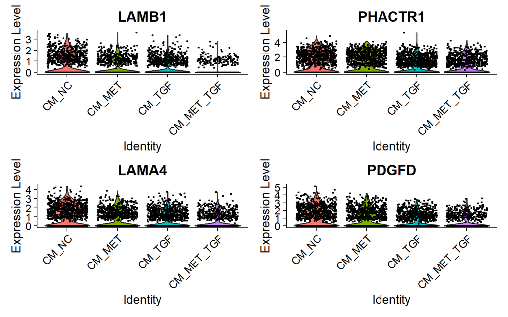

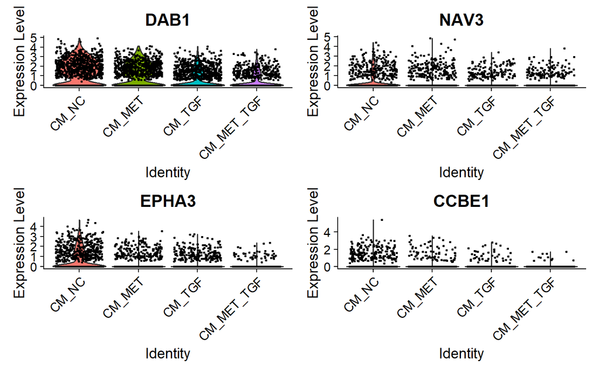

```r
invisible(lapply(plots_tgf_nc, print))
```

### 3.4.3 MET vs NC

#### 3.4.3.1 Gene Extraction

```r
dir.create("results_cardio_extraction_migration", recursive = TRUE)

res_met_nc_migration <- run_pathway_gene_extraction(
  gsea_df = res_hierarchy_met_nc,
  deg_file = "C:/Users/magda/Desktop/Lib_11_MTs_GSEA/deg_MET_vs_NC_cardio.csv",
  category = "Migration",
  output_name = file.path("results_cardio_extraction_migration", "met_vs_nc")
)
```

```
##
## =============================
## Processing category: Migration
## =============================
```

```
##
## Saved: results_cardio_extraction_migration/met_vs_nc_Migration.csv
```

#### 3.4.3.2 Intermediate QC Logs

```r
cat(paste(unlist(res_met_nc_migration$logs), collapse = "\n"))
```

```
##
## [1] CATEGORY FILTER
##
## Rows: 21
##
##
## [2] GENE EXPANSION
##
## Rows: 1419
##
##
## [3] MAPPING
##
## Mapped genes: 233
##
## After merge: 1419 | Missing SYMBOL: 0
##
##
## [4] CLEANING
##
## Rows: 1419
##
##
## [5] GSEA FILTER
##
## Rows: 1419
##
## Unique genes: 233
##
##
## [6] DEG INPUT
##
## Rows: 6919
##
## Filtered DEG: 15
##
##
## [7] INTERSECTION
##
## Final genes: 2
```

#### 3.4.3.3 Extracted Gene Violin Plots

```r
plots_met_nc <- plot_vln_batches(
  seurat_obj = Cardio,
  genes = res_met_nc_migration$genes_final$gene,
  group_by = "Sample",
  ncol = 2,
  nrow = 2,
  output_prefix = "Cardio_Vln_migration_met_nc",
  outdir = "results_cardio_extraction_migration",
  pt.size = 0.5
)
```

```
## Total genes: 2
## Number of batches: 1
```

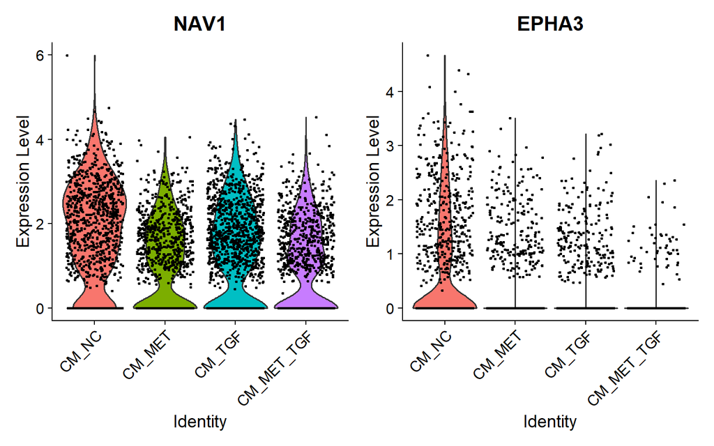

```r
invisible(lapply(plots_met_nc, print))
```

## 3.5 Cell Cycle Category

### 3.5.1 MET_TGF vs TGF

#### 3.5.1.1 Gene Extraction

```r
dir.create("results_cardio_extraction_cellcycle", recursive = TRUE)

res_mettgf_tgf_cellcycle <- run_pathway_gene_extraction(
  gsea_df = res_hierarchy_mettgf_tgf,
  deg_file = "C:/Users/magda/Desktop/Lib_11_MTs_GSEA/deg_MET_TGF_vs_TGF_cardio.csv",
  category = "Cell cycle",
  output_name = file.path("results_cardio_extraction_cellcycle", "mettgf_vs_tgf")
)
```

```
##
## =============================
## Processing category: Cell cycle
## =============================
```

#### 3.5.1.2 Intermediate QC Logs

```r
cat(paste(unlist(res_mettgf_tgf_cellcycle$logs), collapse = "\n"))
```

```
## EMPTY CATEGORY
```

#### 3.5.1.3 Extracted Gene Violin Plots

```r
plots_mettgf_tgf <- plot_vln_batches(
  seurat_obj = Cardio,
  genes = res_mettgf_tgf_cellcycle$genes_final$gene,
  group_by = "Sample",
  ncol = 2,
  nrow = 2,
  output_prefix = "Cardio_Vln_cellcycle_mettgf_tgf",
  outdir = "results_cardio_extraction_cellcycle",
  pt.size = 0.5
)

invisible(lapply(plots_mettgf_tgf, print))
```

### 3.5.2 TGF vs NC

#### 3.5.2.1 Gene Extraction

```r
dir.create("results_cardio_extraction_cellcycle", recursive = TRUE)

res_tgf_nc_cellcycle <- run_pathway_gene_extraction(
  gsea_df = res_hierarchy_tgf_nc,
  deg_file = "C:/Users/magda/Desktop/Lib_11_MTs_GSEA/deg_TGF_vs_NC_cardio.csv",
  category = "Cell cycle",
  output_name = file.path("results_cardio_extraction_cellcycle", "tgf_vs_nc")
)
```

```
##
## =============================
## Processing category: Cell cycle
## =============================
```

#### 3.5.2.2 Intermediate QC Logs

```r
cat(paste(unlist(res_tgf_nc_cellcycle$logs), collapse = "\n"))
```

```
## EMPTY CATEGORY
```

#### 3.5.2.3 Extracted Gene Violin Plots

```r
plots_tgf_nc <- plot_vln_batches(
  seurat_obj = Cardio,
  genes = res_tgf_nc_cellcycle$genes_final$gene,
  group_by = "Sample",
  ncol = 2,
  nrow = 2,
  output_prefix = "Cardio_Vln_cellcycle_tgf_nc",
  outdir = "results_cardio_extraction_cellcycle",
  pt.size = 0.5
)

invisible(lapply(plots_tgf_nc, print))
```

### 3.5.3 MET vs NC

#### 3.5.3.1 Gene Extraction

```r
dir.create("results_cardio_extraction_cellcycle", recursive = TRUE)

res_met_nc_cellcycle <- run_pathway_gene_extraction(
  gsea_df = res_hierarchy_met_nc,
  deg_file = "C:/Users/magda/Desktop/Lib_11_MTs_GSEA/deg_MET_vs_NC_cardio.csv",
  category = "Cell cycle",
  output_name = file.path("results_cardio_extraction_cellcycle", "met_vs_nc")
)
```

```
##
## =============================
## Processing category: Cell cycle
## =============================
```

```
##
## Saved: results_cardio_extraction_cellcycle/met_vs_nc_Cell cycle.csv
```

#### 3.5.3.2 Intermediate QC Logs

```r
cat(paste(unlist(res_met_nc_cellcycle$logs), collapse = "\n"))
```

```
##
## [1] CATEGORY FILTER
##
## Rows: 3
##
##
## [2] GENE EXPANSION
##
## Rows: 388
##
##
## [3] MAPPING
##
## Mapped genes: 212
##
## After merge: 388 | Missing SYMBOL: 0
##
##
## [4] CLEANING
##
## Rows: 388
##
##
## [5] GSEA FILTER
##
## Rows: 388
##
## Unique genes: 212
##
##
## [6] DEG INPUT
##
## Rows: 6919
##
## Filtered DEG: 15
##
##
## [7] INTERSECTION
##
## Final genes: 1
```

#### 3.5.3.3 Extracted Gene Violin Plots

```r
plots_met_nc <- plot_vln_batches(
  seurat_obj = Cardio,
  genes = res_met_nc_cellcycle$genes_final$gene,
  group_by = "Sample",
  ncol = 2,
  nrow = 2,
  output_prefix = "Cardio_Vln_cellcycle_met_nc",
  outdir = "results_cardio_extraction_cellcycle",
  pt.size = 0.5
)
```

```
## Total genes: 1
## Number of batches: 1
```

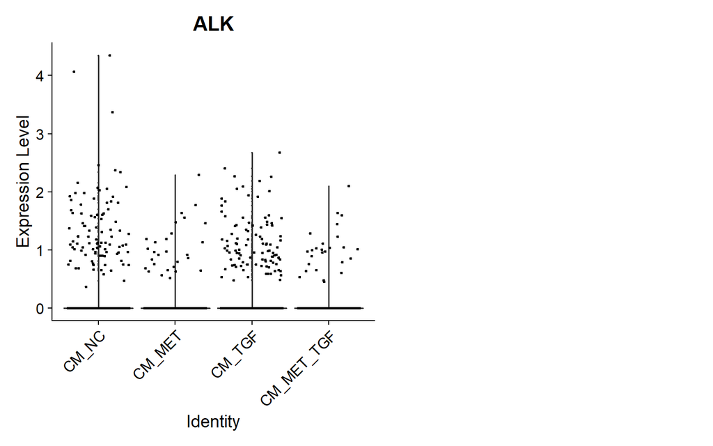

```r
invisible(lapply(plots_met_nc, print))
```

## 3.6 Cell Death Category

### 3.6.1 MET_TGF vs TGF

#### 3.6.1.1 Gene Extraction

```r
dir.create("results_cardio_extraction_celldeath", recursive = TRUE)

res_mettgf_tgf_celldeath <- run_pathway_gene_extraction(
  gsea_df = res_hierarchy_mettgf_tgf,
  deg_file = "C:/Users/magda/Desktop/Lib_11_MTs_GSEA/deg_MET_TGF_vs_TGF_cardio.csv",
  category = "Cell death",
  output_name = file.path("results_cardio_extraction_celldeath", "mettgf_vs_tgf")
)
```

```
##
## =============================
## Processing category: Cell death
## =============================
```

#### 3.6.1.2 Intermediate QC Logs

```r
cat(paste(unlist(res_mettgf_tgf_celldeath$logs), collapse = "\n"))
```

```
## EMPTY CATEGORY
```

#### 3.6.1.3 Extracted Gene Violin Plots

```r
plots_mettgf_tgf <- plot_vln_batches(
  seurat_obj = Cardio,
  genes = res_mettgf_tgf_celldeath$genes_final$gene,
  group_by = "Sample",
  ncol = 2,
  nrow = 2,
  output_prefix = "Cardio_Vln_celldeath_mettgf_tgf",
  outdir = "results_cardio_extraction_celldeath",
  pt.size = 0.5
)

invisible(lapply(plots_mettgf_tgf, print))
```

### 3.6.2 TGF vs NC

#### 3.6.2.1 Gene Extraction

```r
dir.create("results_cardio_extraction_celldeath", recursive = TRUE)

res_tgf_nc_celldeath <- run_pathway_gene_extraction(
  gsea_df = res_hierarchy_tgf_nc,
  deg_file = "C:/Users/magda/Desktop/Lib_11_MTs_GSEA/deg_TGF_vs_NC_cardio.csv",
  category = "Cell death",
  output_name = file.path("results_cardio_extraction_celldeath", "tgf_vs_nc")
)
```

```
##
## =============================
## Processing category: Cell death
## =============================
```

#### 3.6.2.2 Intermediate QC Logs

```r
cat(paste(unlist(res_tgf_nc_celldeath$logs), collapse = "\n"))
```

```
## EMPTY CATEGORY
```

#### 3.6.2.3 Extracted Gene Violin Plots

```r
plots_tgf_nc <- plot_vln_batches(
  seurat_obj = Cardio,
  genes = res_tgf_nc_celldeath$genes_final$gene,
  group_by = "Sample",
  ncol = 2,
  nrow = 2,
  output_prefix = "Cardio_Vln_celldeath_tgf_nc",
  outdir = "results_cardio_extraction_celldeath",
  pt.size = 0.5
)

invisible(lapply(plots_tgf_nc, print))
```

### 3.6.3 MET vs NC

#### 3.6.3.1 Gene Extraction

```r
dir.create("results_cardio_extraction_celldeath", recursive = TRUE)

res_met_nc_celldeath <- run_pathway_gene_extraction(
  gsea_df = res_hierarchy_met_nc,
  deg_file = "C:/Users/magda/Desktop/Lib_11_MTs_GSEA/deg_MET_vs_NC_cardio.csv",
  category = "Cell death",
  output_name = file.path("results_cardio_extraction_celldeath", "met_vs_nc")
)
```

```
##
## =============================
## Processing category: Cell death
## =============================
```

```
##
## Saved: results_cardio_extraction_celldeath/met_vs_nc_Cell death.csv
```

#### 3.6.3.2 Intermediate QC Logs

```r
cat(paste(unlist(res_met_nc_celldeath$logs), collapse = "\n"))
```

```
##
## [1] CATEGORY FILTER
##
## Rows: 3
##
##
## [2] GENE EXPANSION
##
## Rows: 586
##
##
## [3] MAPPING
##
## Mapped genes: 216
##
## After merge: 586 | Missing SYMBOL: 0
##
##
## [4] CLEANING
##
## Rows: 586
##
##
## [5] GSEA FILTER
##
## Rows: 586
##
## Unique genes: 216
##
##
## [6] DEG INPUT
##
## Rows: 6919
##
## Filtered DEG: 15
##
##
## [7] INTERSECTION
##
## Final genes: 1
```

#### 3.6.3.3 Extracted Gene Violin Plots

```r
plots_met_nc <- plot_vln_batches(
  seurat_obj = Cardio,
  genes = res_met_nc_celldeath$genes_final$gene,
  group_by = "Sample",
  ncol = 2,
  nrow = 2,
  output_prefix = "Cardio_Vln_celldeath_met_nc",
  outdir = "results_cardio_extraction_celldeath",
  pt.size = 0.5
)
```

```
## Total genes: 1
## Number of batches: 1
```

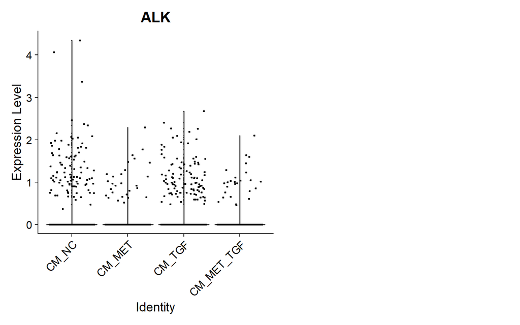

```r
invisible(lapply(plots_met_nc, print))
```

## 3.7 Development Category

### 3.7.1 MET_TGF vs TGF

#### 3.7.1.1 Gene Extraction

```r
dir.create("results_cardio_extraction_development", recursive = TRUE)

res_mettgf_tgf_development <- run_pathway_gene_extraction(
  gsea_df = res_hierarchy_mettgf_tgf,
  deg_file = "C:/Users/magda/Desktop/Lib_11_MTs_GSEA/deg_MET_TGF_vs_TGF_cardio.csv",
  category = "Development",
  output_name = file.path("results_cardio_extraction_development", "mettgf_vs_tgf")
)
```

```
##
## =============================
## Processing category: Development
## =============================
```

```
##
## Saved: results_cardio_extraction_development/mettgf_vs_tgf_Development.csv
```

#### 3.7.1.2 Intermediate QC Logs

```r
cat(paste(unlist(res_mettgf_tgf_development$logs), collapse = "\n"))
```

```
##
## [1] CATEGORY FILTER
##
## Rows: 45
##
##
## [2] GENE EXPANSION
##
## Rows: 2598
##
##
## [3] MAPPING
##
## Mapped genes: 396
##
## After merge: 2598 | Missing SYMBOL: 0
##
##
## [4] CLEANING
##
## Rows: 2598
##
##
## [5] GSEA FILTER
##
## Rows: 2598
##
## Unique genes: 396
##
##
## [6] DEG INPUT
##
## Rows: 6998
##
## Filtered DEG: 35
##
##
## [7] INTERSECTION
##
## Final genes: 15
```

#### 3.7.1.3 Extracted Gene Violin Plots

```r
plots_mettgf_tgf <- plot_vln_batches(
  seurat_obj = Cardio,
  genes = res_mettgf_tgf_development$genes_final$gene,
  group_by = "Sample",
  ncol = 2,
  nrow = 2,
  output_prefix = "Cardio_Vln_development_mettgf_tgf",
  outdir = "results_cardio_extraction_development",
  pt.size = 0.5
)
```

```
## Total genes: 15
## Number of batches: 4
```

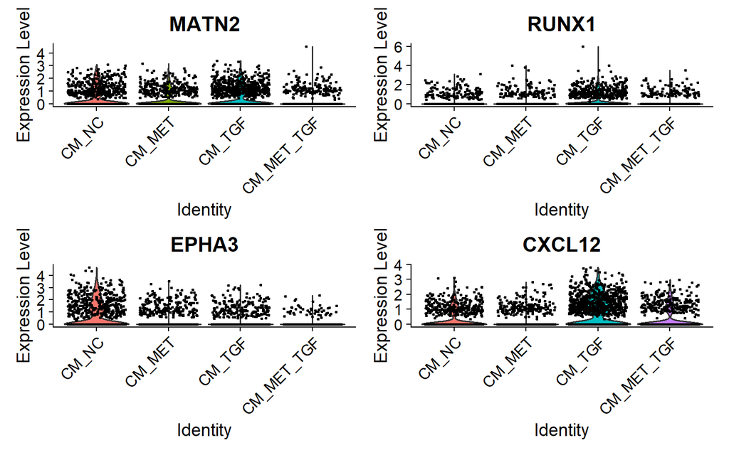

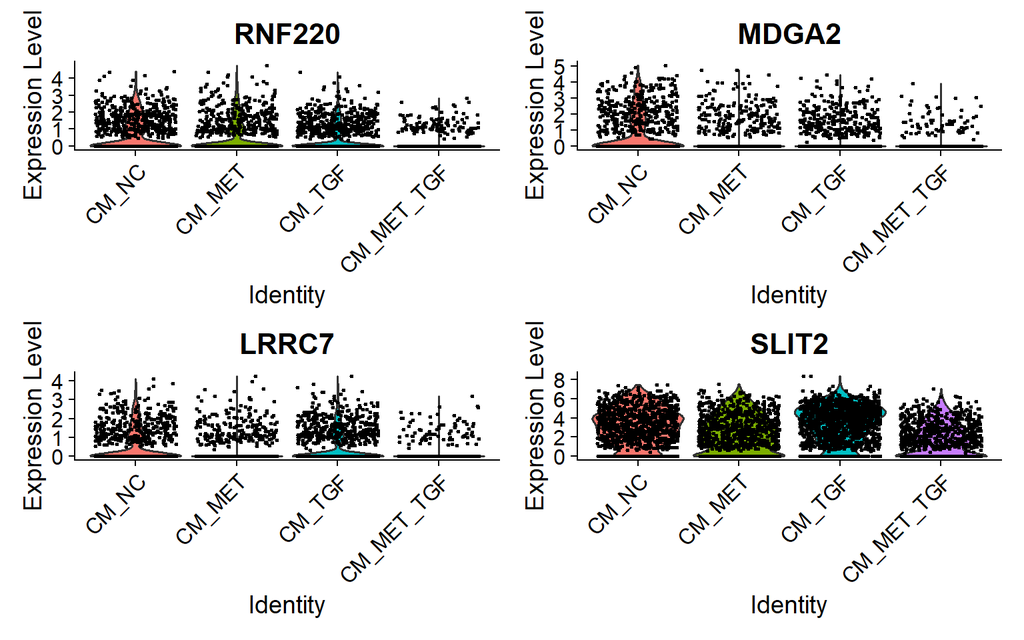

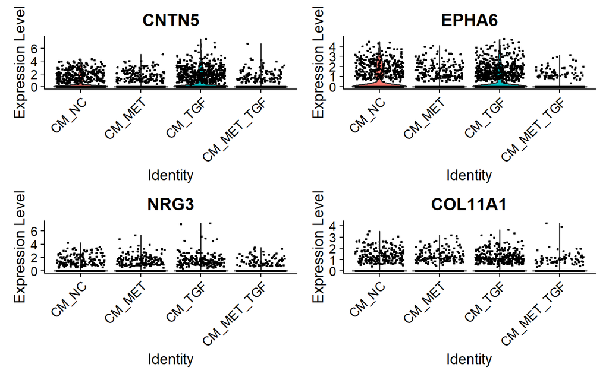

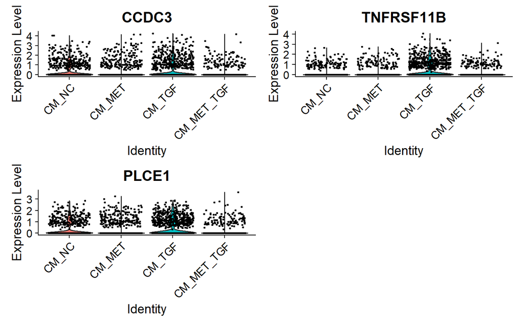

```r
invisible(lapply(plots_mettgf_tgf, print))
```

### 3.7.2 TGF vs NC

#### 3.7.2.1 Gene Extraction

```r
dir.create("results_cardio_extraction_development", recursive = TRUE)

res_tgf_nc_development <- run_pathway_gene_extraction(
  gsea_df = res_hierarchy_tgf_nc,
  deg_file = "C:/Users/magda/Desktop/Lib_11_MTs_GSEA/deg_TGF_vs_NC_cardio.csv",
  category = "Development",
  output_name = file.path("results_cardio_extraction_development", "tgf_vs_nc")
)
```

```
##
## =============================
## Processing category: Development
## =============================
```

```
##
## Saved: results_cardio_extraction_development/tgf_vs_nc_Development.csv
```

#### 3.7.2.2 Intermediate QC Logs

```r
cat(paste(unlist(res_tgf_nc_development$logs), collapse = "\n"))
```

```
##
## [1] CATEGORY FILTER
##
## Rows: 2
##
##
## [2] GENE EXPANSION
##
## Rows: 233
##
##
## [3] MAPPING
##
## Mapped genes: 129
##
## After merge: 233 | Missing SYMBOL: 0
##
##
## [4] CLEANING
##
## Rows: 233
##
##
## [5] GSEA FILTER
##
## Rows: 233
##
## Unique genes: 129
##
##
## [6] DEG INPUT
##
## Rows: 7282
##
## Filtered DEG: 75
##
##
## [7] INTERSECTION
##
## Final genes: 8
```

#### 3.7.2.3 Extracted Gene Violin Plots

```r
plots_tgf_nc <- plot_vln_batches(
  seurat_obj = Cardio,
  genes = res_tgf_nc_development$genes_final$gene,
  group_by = "Sample",
  ncol = 2,
  nrow = 2,
  output_prefix = "Cardio_Vln_development_tgf_nc",
  outdir = "results_cardio_extraction_development",
  pt.size = 0.5
)
```

```
## Total genes: 8
## Number of batches: 2
```

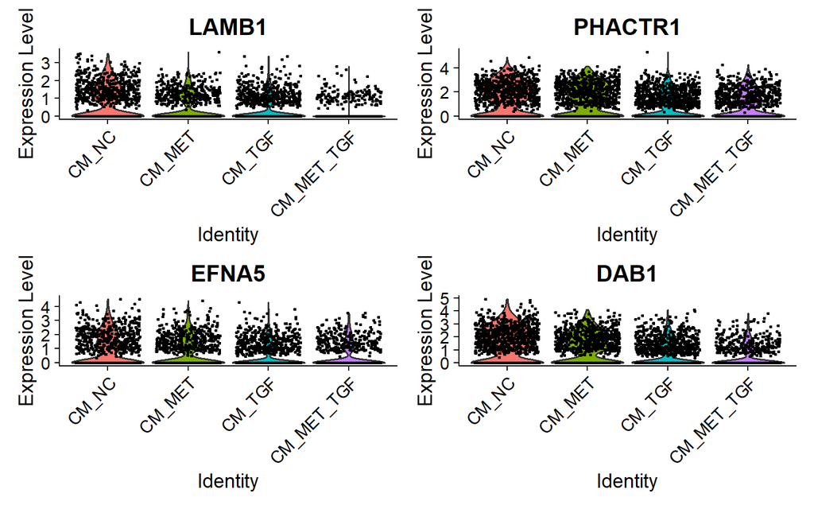

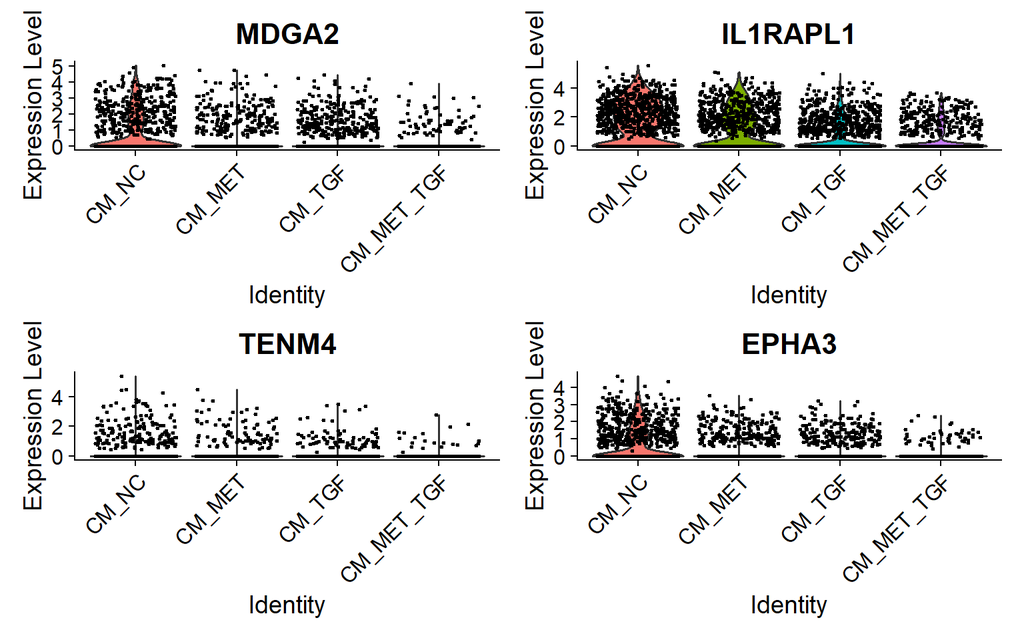

```r
invisible(lapply(plots_tgf_nc, print))
```

### 3.7.3 MET vs NC

#### 3.7.3.1 Gene Extraction

```r
dir.create("results_cardio_extraction_development", recursive = TRUE)

res_met_nc_development <- run_pathway_gene_extraction(
  gsea_df = res_hierarchy_met_nc,
  deg_file = "C:/Users/magda/Desktop/Lib_11_MTs_GSEA/deg_MET_vs_NC_cardio.csv",
  category = "Development",
  output_name = file.path("results_cardio_extraction_development", "met_vs_nc")
)
```

```
##
## =============================
## Processing category: Development
## =============================
```

```
##
## Saved: results_cardio_extraction_development/met_vs_nc_Development.csv
```

#### 3.7.3.2 Intermediate QC Logs

```r
cat(paste(unlist(res_met_nc_development$logs), collapse = "\n"))
```

```
##
## [1] CATEGORY FILTER
##
## Rows: 52
##
##
## [2] GENE EXPANSION
##
## Rows: 4421
##
##
## [3] MAPPING
##
## Mapped genes: 584
##
## After merge: 4421 | Missing SYMBOL: 0
##
##
## [4] CLEANING
##
## Rows: 4421
##
##
## [5] GSEA FILTER
##
## Rows: 4421
##
## Unique genes: 584
##
##
## [6] DEG INPUT
##
## Rows: 6919
##
## Filtered DEG: 15
##
##
## [7] INTERSECTION
##
## Final genes: 4
```

#### 3.7.3.3 Extracted Gene Violin Plots

```r
plots_met_nc <- plot_vln_batches(
  seurat_obj = Cardio,
  genes = res_met_nc_development$genes_final$gene,
  group_by = "Sample",
  ncol = 2,
  nrow = 2,
  output_prefix = "Cardio_Vln_development_met_nc",
  outdir = "results_cardio_extraction_development",
  pt.size = 0.5
)
```

```
## Total genes: 4
## Number of batches: 1
```

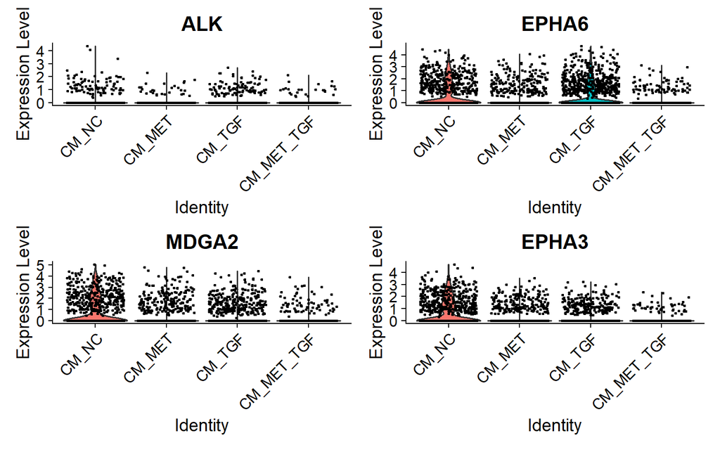

```r
invisible(lapply(plots_met_nc, print))
```